# Analisis Variables Dinamicas

Manuel Rocamora Valenti

2025-04-09

# INTRODUCCIÓN

En el conjunto de datos se ha detectado que algunas variables están disponibles para distintos estados del tratamiento. Para los modelos que vamos a utilizar, podría ser más adecuado introducir un resumen de estas variables. Por ello, vamos a estudiarlas gráficamente y extraer conclusiones para cada una de ellas.

# LIMPIEZA DE DATOS

Vamos a quedarnos tan solo con las variables de interes, el resto las eliminamos.

```r
# Carga de datos
data = read.csv('datos_limpios.csv')

# Eliminamos las columnas que no están duplicadas
library(dplyr)
```

```r
data <- data %>%
  select(
    -Sex, -Age_at_diagnosis, -Elderly, -ECOG, -BMI,
    -Percentage_weight_loss, -Weight_loss_yes_no, -Smoking_habit,
    -Smoking_exposure, -Diabetes, -Cardiopathy, -Neurodegenerative_disease,
    -Histology, -Histology_num, -Stage, -Stage_num, -PD_L1, -Mutation_status,
    -Statins, -Total_cholesterol, -LDH, -CRP, -ALI_pre, -Number_of_cycles,
    -Treatment_interruption, -Interruption_reason, -Progression,
    -Second_line_treatment,-PFS, -PFS_censored, -Education,
    -Household
  )

data
```

| Patient_ID | Total_protein | Albumin | Hemoglobin | Total_leukocytes | Neutrophils | Total_lymphocytes | Platelets | NLR_pre | PLR_pre | PNI_pre | SII_pre | Protein_1C | Albumin_1C | Hemoglobin_1C | Leukocytes_1C | Neutrophils_1C | Lymphocytes_1C | Platelets_1C | NLR_1C | NLR1C_cut4 | NLR1C_cut5 | PLR_1C | PNI_1C | SII_1C | Protein_2C | Albumin_2C | Hemoglobin_2C | Leukocytes_2C | Neutrophils_2C | … |
| --- | --- | --- | --- | --- | --- | --- | --- | --- | --- | --- | --- | --- | --- | --- | --- | --- | --- | --- | --- | --- | --- | --- | --- | --- | --- | --- | --- | --- | --- | --- |
| P_01 | 7.0 | 4.1 | 15.3 | 10100 | 8000 | 1400 | 273000 | 5.714286 | 195.00000 | 48.0 | 1560000.0 | 7.5 | 4.6 | 15.9 | 8100 | 6000 | 1600 | 369000 | 3.750000 | 0 | 0 | 230.62500 | 54.0 | 1383750.0 | 7.9 | 4.5 | 16.5 | 6400 | 3400 | … |
| P_02 | 6.0 | 3.7 | 11.8 | 9800 | 8200 | 800 | 124000 | 10.250000 | 155.00000 | 41.0 | 1271000.0 | 6.2 | 3.9 | 11.7 | 8500 | 7000 | 800 | 112000 | 8.750000 | 1 | 1 | 140.00000 | 43.0 | 980000.0 | 6.1 | 3.7 | 11.4 | 8300 | 6200 | … |
| P_03 | 7.2 | 4.3 | 16.7 | 9900 | 7400 | 1400 | 349000 | 5.285714 | 249.28571 | 50.0 | 1844714.3 | 7.2 | 4.4 | 16.1 | 12000 | 8000 | 2500 | 382000 | 3.200000 | 0 | 0 | 152.80000 | 56.5 | 1222400.0 | 7.2 | 4.4 | 16.7 | 8400 | 4500 | … |
| P_04 | 7.1 | 4.0 | 14.6 | 5600 | 3000 | 1800 | 220000 | 1.666667 | 122.22222 | 49.0 | 366666.7 | 7.7 | 3.1 | 15.5 | 7300 | 4400 | 2000 | 266000 | 2.200000 | 0 | 0 | 133.00000 | 10.0 | 585200.0 | 7.2 | 4.1 | 15.3 | 7200 | 4300 | … |
| P_05 | 7.9 | 4.4 | 15.7 | 8900 | 5300 | 2300 | 350000 | 2.304348 | 152.17391 | 55.5 | 806521.7 | 7.4 | 4.5 | 15.9 | 9200 | 4900 | 3100 | 364000 | 1.580645 | 0 | 0 | 117.41935 | 60.5 | 575354.8 | 8.0 | 4.5 | 16.3 | 9200 | 5100 | … |
| P_06 | 8.0 | 4.3 | 13.1 | 8800 | 6000 | 1600 | 279000 | 3.750000 | 174.37500 | 51.0 | 1046250.0 | 8.1 | 4.2 | 14.5 | 8000 | 5300 | 1600 | 293000 | 3.312500 | 0 | 0 | 183.12500 | 50.0 | 970562.5 | 8.1 | 4.5 | 15.5 | 8000 | 5300 | … |
| P_07 | 6.4 | 3.6 | 11.5 | 10000 | 9000 | 400 | 269000 | 22.500000 | 672.50000 | 38.0 | 6052500.0 | 6.5 | 4.0 | 11.6 | 4500 | 3200 | 900 | 218000 | 3.555556 | 0 | 0 | 242.22222 | 44.5 | 775111.1 | 7.2 | 4.1 | 12.4 | 8200 | 6400 | … |
| P_08 | 7.0 | 3.9 | 12.3 | 7700 | 5300 | 1600 | 201000 | 3.312500 | 125.62500 | 47.0 | 665812.5 | 7.7 | 4.0 | 12.1 | 3600 | 1900 | 900 | 131000 | 2.111111 | 0 | 0 | 145.55556 | 44.5 | 276555.6 | 6.9 | 4.0 | 12.3 | 7600 | 3400 | … |
| P_09 | 6.9 | 3.7 | 12.9 | 16200 | 13200 | 1900 | 317000 | 6.947368 | 166.84211 | 46.5 | 2202315.8 | 7.4 | 3.9 | 14.5 | 16100 | 12100 | 2900 | 380000 | 4.172414 | 1 | 0 | 131.03448 | 53.5 | 1585517.2 | 7.2 | 3.7 | 13.4 | 19400 | 16100 | … |
| P_10 | 7.3 | 4.0 | 13.0 | 15700 | 13400 | 1400 | 324000 | 9.571429 | 231.42857 | 47.0 | 3101142.9 | 7.4 | 4.0 | 13.5 | 12800 | 9800 | 1900 | 214000 | 5.157895 | 1 | 1 | 112.63158 | 49.5 | 1103789.5 | 7.5 | 4.1 | 13.4 | 8700 | 5500 | … |

[output cut: 24 more lines]

# ANÁLISIS VARIABLE A VARIABLE

Vamos a ir, variable a variables, estudiando su comportamiento temporal y correlación, veremos si existe mucha correlación o no entre ellas, con la idea de agruparlas dado el caso.

## Proteina

```r
library(tidyverse)
```

```r
library(plotly)
vars_proteina <- c("Total_protein", "Protein_1C", "Protein_2C", "Protein_1eval")

df_long1 <- data %>%
  select(Patient_ID, Mejor_resp, all_of(vars_proteina)) %>%
  pivot_longer(cols = all_of(vars_proteina), names_to = "Momento", values_to = "Valor") %>%
  mutate(Momento = factor(Momento, levels = vars_proteina))  # <- AQUÍ está la clave

g1 <- ggplot(df_long1, aes(x = Momento, y = Valor, group = Patient_ID, color = as.factor(Mejor_resp))) +
  geom_line(alpha = 0.7) +
  geom_point(size = 1.5, alpha = 0.9) +
  theme_minimal() +
  labs(
    title = "Evolución de proteína por paciente",
    subtitle = "Color según mejor respuesta al tratamiento",
    x = "Momento",
    y = "Valor proteína",
    color = "Mejor respuesta"
  )

ggplotly(g1)
```

[interactive chart not shown]

```r
df_long2 <- data %>%
  select(Patient_ID, First_eval, all_of(vars_proteina)) %>%
  pivot_longer(cols = all_of(vars_proteina), names_to = "Momento", values_to = "Valor") %>%
  mutate(Momento = factor(Momento, levels = vars_proteina))  # <- Orden correcto

g2 <- ggplot(df_long2, aes(
  x = Momento,
  y = Valor,
  group = Patient_ID,
  color = as.factor(First_eval)
)) +
  geom_line(alpha = 0.7) +
  geom_point(size = 1.5, alpha = 0.9) +
  theme_minimal() +
  labs(
    title = "Evolución de proteína por paciente",
    subtitle = "Color según mejor respuesta al tratamiento",
    x = "Momento",
    y = "Valor proteína",
    color = "First_eval"
  )

ggplotly(g2)
```

[interactive chart not shown]

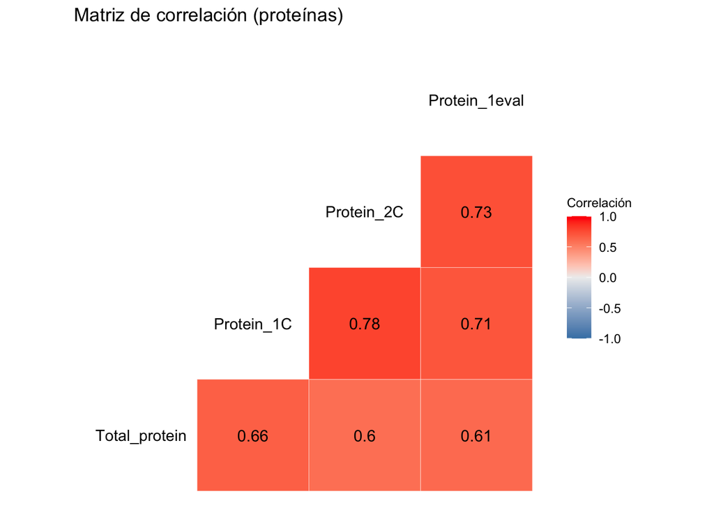

```r
library(GGally)
# Selección de las variables a correlacionar
vars_proteina <- c("Total_protein", "Protein_1C", "Protein_2C", "Protein_1eval")
df_corr <- data %>% select(all_of(vars_proteina))

# Gráfico de correlación
ggcorr(df_corr,
       label = TRUE,
       label_round = 2,
       label_size = 4,
       low = "steelblue", high = "red",
       name = "Correlación") +
  ggtitle("Matriz de correlación (proteínas)")
```

Correlaciones moderadas-altas (0.60–0.78) → variables relacionadas pero no idénticas. Se puede considerar resumir, aunque podrían aportar info complementaria.

## Albumin

```r
# Variables longitudinales de Albumina
vars_Albumin <- c("Albumin", "Albumin_1C", "Albumin_2C", "Albumin_1eval")

# =====================
# GRÁFICO 1 - Color por Mejor_resp
# =====================
df_long1 <- data %>%
  select(Patient_ID, Mejor_resp, all_of(vars_Albumin)) %>%
  pivot_longer(cols = all_of(vars_Albumin), names_to = "Momento", values_to = "Valor") %>%
  mutate(Momento = factor(Momento, levels = vars_Albumin))  # Orden explícito

g1 <- ggplot(df_long1, aes(
  x = Momento,
  y = Valor,
  group = Patient_ID,
  color = as.factor(Mejor_resp),
  text = paste(
    "Paciente:", Patient_ID,
    "<br>Momento:", Momento,
    "<br>Valor:", round(Valor, 2),
    "<br>Mejor respuesta:", Mejor_resp
  )
)) +
  geom_line(alpha = 0.7) +
  geom_point(size = 1.5, alpha = 0.9) +
  theme_minimal() +
  labs(
    title = "Evolución de Albumina por paciente",
    subtitle = "Color según mejor respuesta al tratamiento",
    x = "Momento",
    y = "Valor Albumina",
    color = "Mejor respuesta"
  )

ggplotly(g1, tooltip = "text")
```

[interactive chart not shown]

```r
# =====================
# GRÁFICO 2 - Color por First_eval
# =====================
df_long2 <- data %>%
  select(Patient_ID, First_eval, all_of(vars_Albumin)) %>%
  pivot_longer(cols = all_of(vars_Albumin), names_to = "Momento", values_to = "Valor") %>%
  mutate(Momento = factor(Momento, levels = vars_Albumin))  # Orden explícito

g2 <- ggplot(df_long2, aes(
  x = Momento,
  y = Valor,
  group = Patient_ID,
  color = as.factor(First_eval),
  text = paste(
    "Paciente:", Patient_ID,
    "<br>Momento:", Momento,
    "<br>Valor:", round(Valor, 2),
    "<br>1ª evaluación:", First_eval
  )
)) +
  geom_line(alpha = 0.7) +
  geom_point(size = 1.5, alpha = 0.9) +
  theme_minimal() +
  labs(
    title = "Evolución de Albumina por paciente",
    subtitle = "Color según 1ª evaluación",
    x = "Momento",
    y = "Valor Albumina",
    color = "First_eval"
  )

ggplotly(g2, tooltip = "text")
```

[interactive chart not shown]

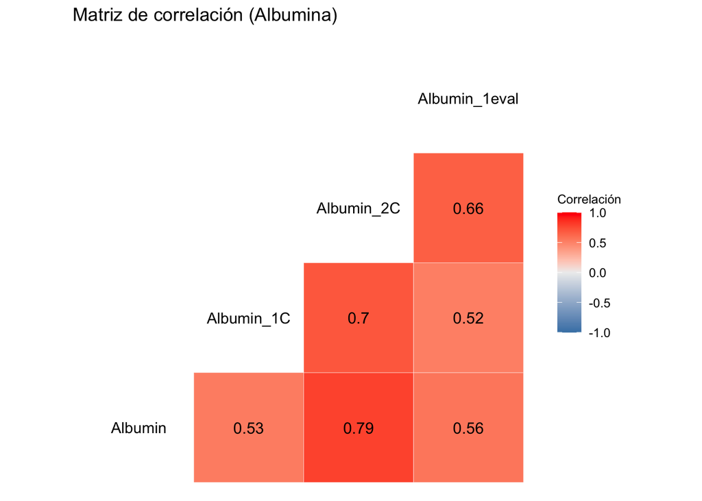

```r
# =====================
# MATRIZ DE CORRELACIÓN
# =====================
df_corr <- data %>% select(all_of(vars_Albumin))

ggcorr(df_corr,
       label = TRUE,
       label_round = 2,
       label_size = 4,
       low = "steelblue", high = "red",
       name = "Correlación") +
  ggtitle("Matriz de correlación (Albumina)")
```

## Hemoglobin

```r
vars_Hemo <- c("Hemoglobin", "Hemoglobin_1C", "Hemoglobin_2C", "Hemoglobin_1eval")

# Gráfico 1 - Mejor_resp
df_long1 <- data %>%
  select(Patient_ID, Mejor_resp, all_of(vars_Hemo)) %>%
  pivot_longer(cols = all_of(vars_Hemo), names_to = "Momento", values_to = "Valor") %>%
  mutate(Momento = factor(Momento, levels = vars_Hemo))

g1 <- ggplot(df_long1, aes(
  x = Momento, y = Valor,
  group = Patient_ID, color = as.factor(Mejor_resp)
)) +
  geom_line(alpha = 0.7) +
  geom_point(size = 1.5, alpha = 0.9) +
  theme_minimal() +
  labs(
    title = "Evolución de Hemo por paciente",
    subtitle = "Color según mejor respuesta al tratamiento",
    x = "Momento", y = "Valor Hemo",
    color = "Mejor respuesta"
  )

ggplotly(g1)
```

[interactive chart not shown]

```r
# Gráfico 2 - First_eval
df_long2 <- data %>%
  select(Patient_ID, First_eval, all_of(vars_Hemo)) %>%
  pivot_longer(cols = all_of(vars_Hemo), names_to = "Momento", values_to = "Valor") %>%
  mutate(Momento = factor(Momento, levels = vars_Hemo))

g2 <- ggplot(df_long2, aes(
  x = Momento, y = Valor,
  group = Patient_ID, color = as.factor(First_eval)
)) +
  geom_line(alpha = 0.7) +
  geom_point(size = 1.5, alpha = 0.9) +
  theme_minimal() +
  labs(
    title = "Evolución de Hemo por paciente",
    subtitle = "Color según mejor respuesta al tratamiento",
    x = "Momento", y = "Valor Hemo",
    color = "First_eval"
  )

ggplotly(g2)
```

[interactive chart not shown]

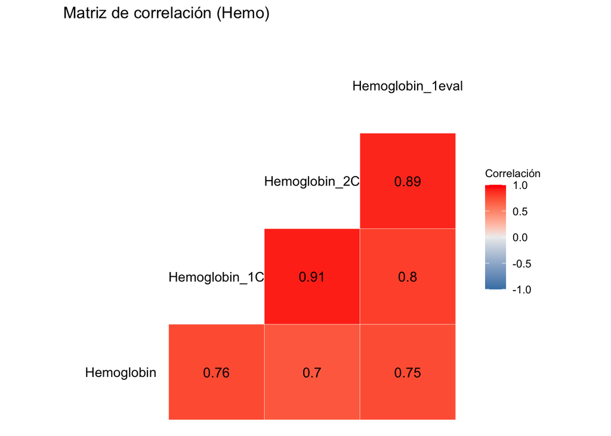

```r
# Matriz de correlación
df_corr <- data %>% select(all_of(vars_Hemo))

ggcorr(df_corr,
       label = TRUE,
       label_round = 2,
       label_size = 4,
       low = "steelblue", high = "red",
       name = "Correlación") +
  ggtitle("Matriz de correlación (Hemo)")
```

Alta correlación

## Leukocytes

```r
# Variables longitudinales de leucocitos
vars_Leuko <- c("Total_leukocytes", "Leukocytes_1C", "Leukocytes_2C", "Leukocytes_1eval")

# =====================
# GRÁFICO 1 - Color por Mejor_resp
# =====================
df_long1 <- data %>%
  select(Patient_ID, Mejor_resp, all_of(vars_Leuko)) %>%
  pivot_longer(cols = all_of(vars_Leuko), names_to = "Momento", values_to = "Valor") %>%
  mutate(Momento = factor(Momento, levels = vars_Leuko))

g1 <- ggplot(df_long1, aes(
  x = Momento,
  y = Valor,
  group = Patient_ID,
  color = as.factor(Mejor_resp),
  text = paste(
    "Paciente:", Patient_ID,
    "<br>Momento:", Momento,
    "<br>Valor:", round(Valor, 2),
    "<br>Mejor respuesta:", Mejor_resp
  )
)) +
  geom_line(alpha = 0.7) +
  geom_point(size = 1.5, alpha = 0.9) +
  theme_minimal() +
  labs(
    title = "Evolución de leucocitos por paciente",
    subtitle = "Color según mejor respuesta al tratamiento",
    x = "Momento",
    y = "Valor leucocitos",
    color = "Mejor respuesta"
  )

ggplotly(g1, tooltip = "text")
```

[interactive chart not shown]

```r
# =====================
# GRÁFICO 2 - Color por 1ª_eval
# =====================
df_long2 <- data %>%
  select(Patient_ID, First_eval, all_of(vars_Leuko)) %>%
  pivot_longer(cols = all_of(vars_Leuko), names_to = "Momento", values_to = "Valor") %>%
  mutate(Momento = factor(Momento, levels = vars_Leuko))

g2 <- ggplot(df_long2, aes(
  x = Momento,
  y = Valor,
  group = Patient_ID,
  color = as.factor(First_eval),
  text = paste(
    "Paciente:", Patient_ID,
    "<br>Momento:", Momento,
    "<br>Valor:", round(Valor, 2),
    "<br>1ª evaluación:", First_eval
  )
)) +
  geom_line(alpha = 0.7) +
  geom_point(size = 1.5, alpha = 0.9) +
  theme_minimal() +
  labs(
    title = "Evolución de leucocitos por paciente",
    subtitle = "Color según 1ª evaluación",
    x = "Momento",
    y = "Valor leucocitos",
    color = "1ª evaluación"
  )

ggplotly(g2, tooltip = "text")
```

[interactive chart not shown]

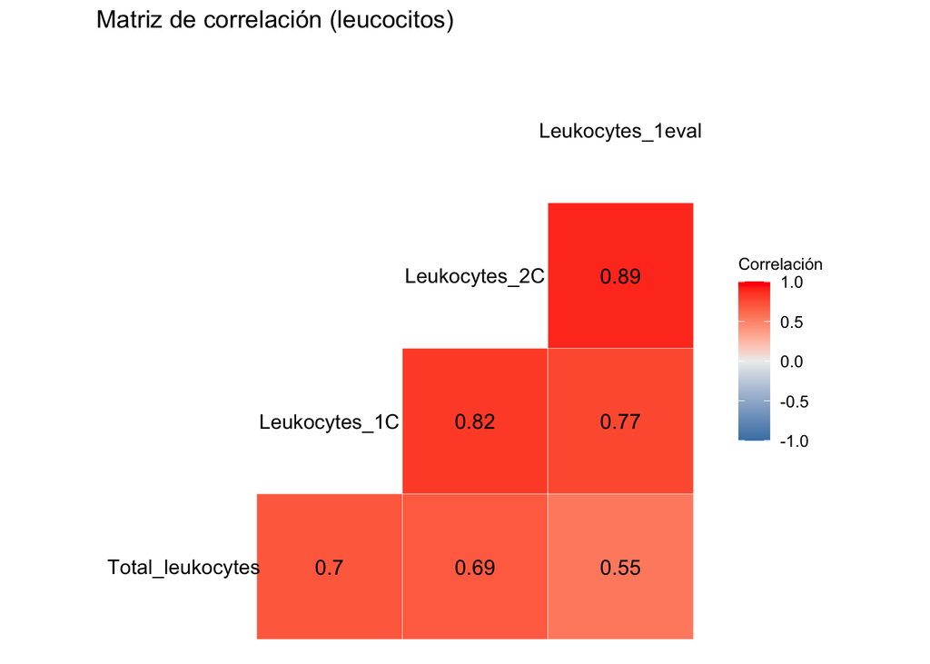

```r
# =====================
# MATRIZ DE CORRELACIÓN
# =====================
df_corr <- data %>% select(all_of(vars_Leuko))

ggcorr(df_corr,
       label = TRUE,
       label_round = 2,
       label_size = 4,
       low = "steelblue", high = "red",
       name = "Correlación") +
  ggtitle("Matriz de correlación (leucocitos)")
```

Alta correlación, excepto el Total con el Final de los leukocitos

## Neutrofilos

```r
# Variables longitudinales de neutrófilos
vars_Neutro <- c("Neutrophils", "Neutrophils_1C", "Neutrophils_2C", "Neutrophils_1eval")

# =====================
# GRÁFICO 1 - Color por Mejor_resp
# =====================
df_long1 <- data %>%
  select(Patient_ID, Mejor_resp, all_of(vars_Neutro)) %>%
  pivot_longer(cols = all_of(vars_Neutro), names_to = "Momento", values_to = "Valor") %>%
  mutate(Momento = factor(Momento, levels = vars_Neutro))

g1 <- ggplot(df_long1, aes(
  x = Momento,
  y = Valor,
  group = Patient_ID,
  color = as.factor(Mejor_resp),
  text = paste(
    "Paciente:", Patient_ID,
    "<br>Momento:", Momento,
    "<br>Valor:", round(Valor, 2),
    "<br>Mejor respuesta:", Mejor_resp
  )
)) +
  geom_line(alpha = 0.7) +
  geom_point(size = 1.5, alpha = 0.9) +
  theme_minimal() +
  labs(
    title = "Evolución de neutrófilos por paciente",
    subtitle = "Color según mejor respuesta al tratamiento",
    x = "Momento",
    y = "Valor neutrófilos",
    color = "Mejor respuesta"
  )

ggplotly(g1, tooltip = "text")
```

[interactive chart not shown]

```r
# =====================
# GRÁFICO 2 - Color por First_eval
# =====================
df_long2 <- data %>%
  select(Patient_ID, First_eval, all_of(vars_Neutro)) %>%
  pivot_longer(cols = all_of(vars_Neutro), names_to = "Momento", values_to = "Valor") %>%
  mutate(Momento = factor(Momento, levels = vars_Neutro))

g2 <- ggplot(df_long2, aes(
  x = Momento,
  y = Valor,
  group = Patient_ID,
  color = as.factor(First_eval),
  text = paste(
    "Paciente:", Patient_ID,
    "<br>Momento:", Momento,
    "<br>Valor:", round(Valor, 2),
    "<br>1ª evaluación:", First_eval
  )
)) +
  geom_line(alpha = 0.7) +
  geom_point(size = 1.5, alpha = 0.9) +
  theme_minimal() +
  labs(
    title = "Evolución de neutrófilos por paciente",
    subtitle = "Color según 1ª evaluación",
    x = "Momento",
    y = "Valor neutrófilos",
    color = "1ª evaluación"
  )

ggplotly(g2, tooltip = "text")
```

[interactive chart not shown]

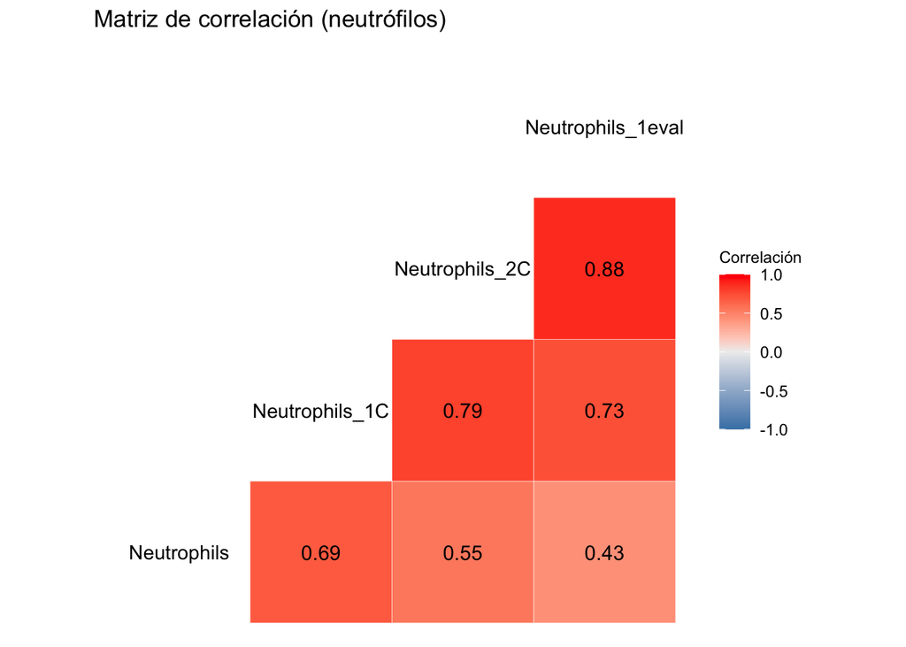

```r
# =====================
# MATRIZ DE CORRELACIÓN
# =====================
df_corr <- data %>% select(all_of(vars_Neutro))

ggcorr(df_corr,
       label = TRUE,
       label_round = 2,
       label_size = 4,
       low = "steelblue", high = "red",
       name = "Correlación") +
  ggtitle("Matriz de correlación (neutrófilos)")
```

## Linfocitos

```r
# Variables longitudinales de linfocitos
vars_Lympho <- c("Total_lymphocytes", "Lymphocytes_1C", "Lymphocytes_2C", "Lymphocytes_1eval")

# =====================
# GRÁFICO 1 - Color por Mejor_resp
# =====================
df_long1 <- data %>%
  select(Patient_ID, Mejor_resp, all_of(vars_Lympho)) %>%
  pivot_longer(cols = all_of(vars_Lympho), names_to = "Momento", values_to = "Valor") %>%
  mutate(Momento = factor(Momento, levels = vars_Lympho))

g1 <- ggplot(df_long1, aes(
  x = Momento,
  y = Valor,
  group = Patient_ID,
  color = as.factor(Mejor_resp),
  text = paste(
    "Paciente:", Patient_ID,
    "<br>Momento:", Momento,
    "<br>Valor:", round(Valor, 2),
    "<br>Mejor respuesta:", Mejor_resp
  )
)) +
  geom_line(alpha = 0.7) +
  geom_point(size = 1.5, alpha = 0.9) +
  theme_minimal() +
  labs(
    title = "Evolución de linfocitos por paciente",
    subtitle = "Color según mejor respuesta al tratamiento",
    x = "Momento",
    y = "Valor linfocitos",
    color = "Mejor respuesta"
  )

ggplotly(g1, tooltip = "text")
```

[interactive chart not shown]

```r
# =====================
# GRÁFICO 2 - Color por First_eval
# =====================
df_long2 <- data %>%
  select(Patient_ID, First_eval, all_of(vars_Lympho)) %>%
  pivot_longer(cols = all_of(vars_Lympho), names_to = "Momento", values_to = "Valor") %>%
  mutate(Momento = factor(Momento, levels = vars_Lympho))

g2 <- ggplot(df_long2, aes(
  x = Momento,
  y = Valor,
  group = Patient_ID,
  color = as.factor(First_eval),
  text = paste(
    "Paciente:", Patient_ID,
    "<br>Momento:", Momento,
    "<br>Valor:", round(Valor, 2),
    "<br>1ª evaluación:", First_eval
  )
)) +
  geom_line(alpha = 0.7) +
  geom_point(size = 1.5, alpha = 0.9) +
  theme_minimal() +
  labs(
    title = "Evolución de linfocitos por paciente",
    subtitle = "Color según 1ª evaluación",
    x = "Momento",
    y = "Valor linfocitos",
    color = "1ª evaluación"
  )

ggplotly(g2, tooltip = "text")
```

[interactive chart not shown]

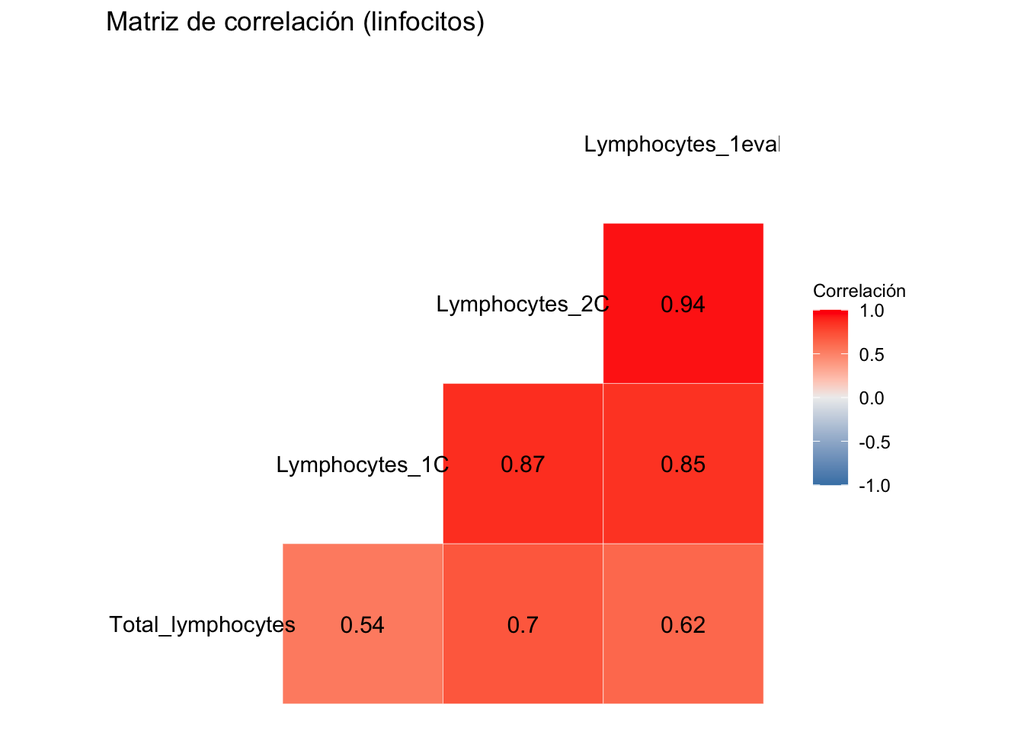

```r
# =====================
# MATRIZ DE CORRELACIÓN
# =====================
df_corr <- data %>% select(all_of(vars_Lympho))

ggcorr(df_corr,
       label = TRUE,
       label_round = 2,
       label_size = 4,
       low = "steelblue", high = "red",
       name = "Correlación") +
  ggtitle("Matriz de correlación (linfocitos)")
```

## Plaquetas

```r
# Variables longitudinales de plaquetas
vars_Platelets <- c("Platelets", "Platelets_1C", "Platelets_2C", "Platelets_1eval")

# =====================
# GRÁFICO 1 - Color por Mejor_resp
# =====================
df_long1 <- data %>%
  select(Patient_ID, Mejor_resp, all_of(vars_Platelets)) %>%
  pivot_longer(cols = all_of(vars_Platelets), names_to = "Momento", values_to = "Valor") %>%
  mutate(Momento = factor(Momento, levels = vars_Platelets))

g1 <- ggplot(df_long1, aes(
  x = Momento,
  y = Valor,
  group = Patient_ID,
  color = as.factor(Mejor_resp),
  text = paste(
    "Paciente:", Patient_ID,
    "<br>Momento:", Momento,
    "<br>Valor:", round(Valor, 2),
    "<br>Mejor respuesta:", Mejor_resp
  )
)) +
  geom_line(alpha = 0.7) +
  geom_point(size = 1.5, alpha = 0.9) +
  theme_minimal() +
  labs(
    title = "Evolución de plaquetas por paciente",
    subtitle = "Color según mejor respuesta al tratamiento",
    x = "Momento",
    y = "Valor plaquetas",
    color = "Mejor respuesta"
  )

ggplotly(g1, tooltip = "text")
```

[interactive chart not shown]

```r
# =====================
# GRÁFICO 2 - Color por First_eval
# =====================
df_long2 <- data %>%
  select(Patient_ID, First_eval, all_of(vars_Platelets)) %>%
  pivot_longer(cols = all_of(vars_Platelets), names_to = "Momento", values_to = "Valor") %>%
  mutate(Momento = factor(Momento, levels = vars_Platelets))

g2 <- ggplot(df_long2, aes(
  x = Momento,
  y = Valor,
  group = Patient_ID,
  color = as.factor(First_eval),
  text = paste(
    "Paciente:", Patient_ID,
    "<br>Momento:", Momento,
    "<br>Valor:", round(Valor, 2),
    "<br>1ª evaluación:", First_eval
  )
)) +
  geom_line(alpha = 0.7) +
  geom_point(size = 1.5, alpha = 0.9) +
  theme_minimal() +
  labs(
    title = "Evolución de plaquetas por paciente",
    subtitle = "Color según 1ª evaluación",
    x = "Momento",
    y = "Valor plaquetas",
    color = "1ª evaluación"
  )

ggplotly(g2, tooltip = "text")
```

[interactive chart not shown]

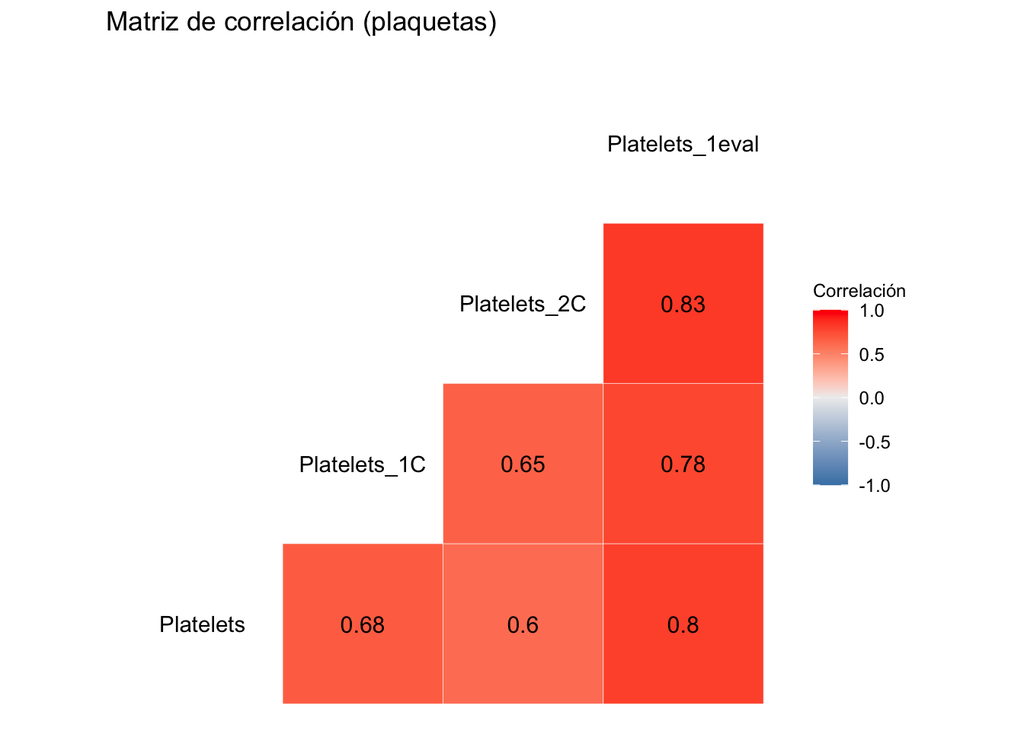

```r
# =====================
# MATRIZ DE CORRELACIÓN
# =====================
df_corr <- data %>% select(all_of(vars_Platelets))

ggcorr(df_corr,
       label = TRUE,
       label_round = 2,
       label_size = 4,
       low = "steelblue", high = "red",
       name = "Correlación") +
  ggtitle("Matriz de correlación (plaquetas)")
```

## NLR

```r
# Variables longitudinales de NLR
vars_NLR <- c("NLR_pre", "NLR_1C", "NLR_2C", "NLR_1eval")

# =====================
# GRÁFICO 1 - Color por Mejor_resp
# =====================
df_long1 <- data %>%
  select(Patient_ID, Mejor_resp, all_of(vars_NLR)) %>%
  pivot_longer(cols = all_of(vars_NLR), names_to = "Momento", values_to = "Valor") %>%
  mutate(Momento = factor(Momento, levels = vars_NLR))

g1 <- ggplot(df_long1, aes(
  x = Momento,
  y = Valor,
  group = Patient_ID,
  color = as.factor(Mejor_resp),
  text = paste(
    "Paciente:", Patient_ID,
    "<br>Momento:", Momento,
    "<br>Valor:", round(Valor, 2),
    "<br>Mejor respuesta:", Mejor_resp
  )
)) +
  geom_line(alpha = 0.7) +
  geom_point(size = 1.5, alpha = 0.9) +
  theme_minimal() +
  labs(
    title = "Evolución del NLR por paciente",
    subtitle = "Color según mejor respuesta al tratamiento",
    x = "Momento",
    y = "Valor NLR",
    color = "Mejor respuesta"
  )

ggplotly(g1, tooltip = "text")
```

[interactive chart not shown]

```r
# =====================
# GRÁFICO 2 - Color por First_eval
# =====================
df_long2 <- data %>%
  select(Patient_ID, First_eval, all_of(vars_NLR)) %>%
  pivot_longer(cols = all_of(vars_NLR), names_to = "Momento", values_to = "Valor") %>%
  mutate(Momento = factor(Momento, levels = vars_NLR))

g2 <- ggplot(df_long2, aes(
  x = Momento,
  y = Valor,
  group = Patient_ID,
  color = as.factor(First_eval),
  text = paste(
    "Paciente:", Patient_ID,
    "<br>Momento:", Momento,
    "<br>Valor:", round(Valor, 2),
    "<br>1ª evaluación:", First_eval
  )
)) +
  geom_line(alpha = 0.7) +
  geom_point(size = 1.5, alpha = 0.9) +
  theme_minimal() +
  labs(
    title = "Evolución del NLR por paciente",
    subtitle = "Color según 1ª evaluación",
    x = "Momento",
    y = "Valor NLR",
    color = "1ª evaluación"
  )

ggplotly(g2, tooltip = "text")
```

[interactive chart not shown]

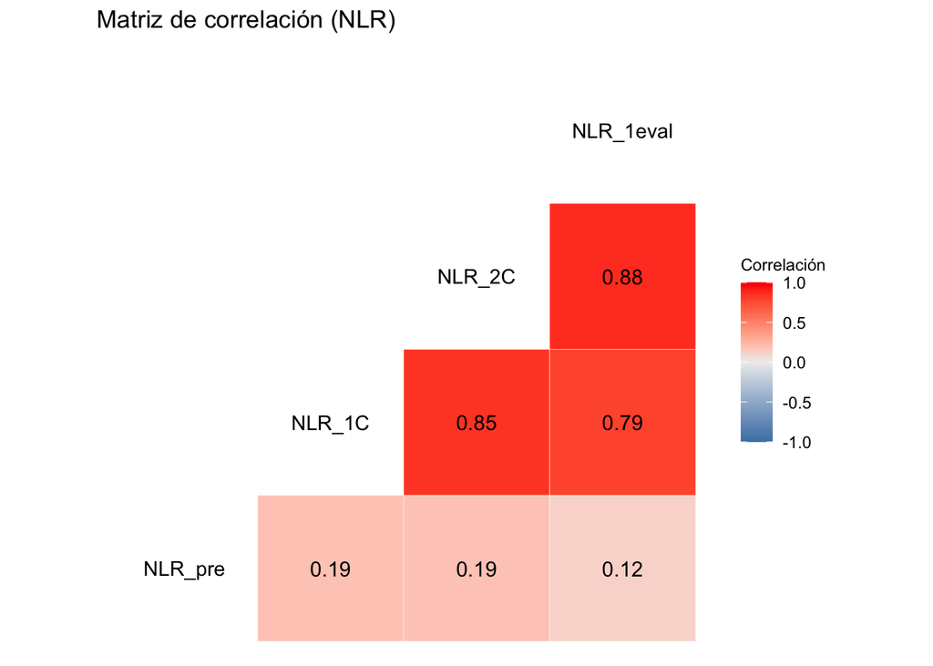

```r
# =====================
# MATRIZ DE CORRELACIÓN
# =====================
df_corr <- data %>% select(all_of(vars_NLR))

ggcorr(df_corr,
       label = TRUE,
       label_round = 2,
       label_size = 4,
       low = "steelblue", high = "red",
       name = "Correlación") +
  ggtitle("Matriz de correlación (NLR)")
```

Podriamos guardar NLR_pre y resumir el resto, ya que la diferencia es significativa, no tienen casi correlación.

## PLR

```r
# Variables longitudinales de PLR
vars_PLR <- c("PLR_pre", "PLR_1C", "PLR_2C", "PLR_1eval")

# =====================
# GRÁFICO 1 - Color por Mejor_resp
# =====================
df_long1 <- data %>%
  select(Patient_ID, Mejor_resp, all_of(vars_PLR)) %>%
  pivot_longer(cols = all_of(vars_PLR), names_to = "Momento", values_to = "Valor") %>%
  mutate(Momento = factor(Momento, levels = vars_PLR))

g1 <- ggplot(df_long1, aes(
  x = Momento,
  y = Valor,
  group = Patient_ID,
  color = as.factor(Mejor_resp),
  text = paste(
    "Paciente:", Patient_ID,
    "<br>Momento:", Momento,
    "<br>Valor:", round(Valor, 2),
    "<br>Mejor respuesta:", Mejor_resp
  )
)) +
  geom_line(alpha = 0.7) +
  geom_point(size = 1.5, alpha = 0.9) +
  theme_minimal() +
  labs(
    title = "Evolución del PLR por paciente",
    subtitle = "Color según mejor respuesta al tratamiento",
    x = "Momento",
    y = "Valor PLR",
    color = "Mejor respuesta"
  )

ggplotly(g1, tooltip = "text")
```

[interactive chart not shown]

```r
# =====================
# GRÁFICO 2 - Color por First_eval
# =====================
df_long2 <- data %>%
  select(Patient_ID, First_eval, all_of(vars_PLR)) %>%
  pivot_longer(cols = all_of(vars_PLR), names_to = "Momento", values_to = "Valor") %>%
  mutate(Momento = factor(Momento, levels = vars_PLR))

g2 <- ggplot(df_long2, aes(
  x = Momento,
  y = Valor,
  group = Patient_ID,
  color = as.factor(First_eval),
  text = paste(
    "Paciente:", Patient_ID,
    "<br>Momento:", Momento,
    "<br>Valor:", round(Valor, 2),
    "<br>1ª evaluación:", First_eval
  )
)) +
  geom_line(alpha = 0.7) +
  geom_point(size = 1.5, alpha = 0.9) +
  theme_minimal() +
  labs(
    title = "Evolución del PLR por paciente",
    subtitle = "Color según 1ª evaluación",
    x = "Momento",
    y = "Valor PLR",
    color = "1ª evaluación"
  )

ggplotly(g2, tooltip = "text")
```

[interactive chart not shown]

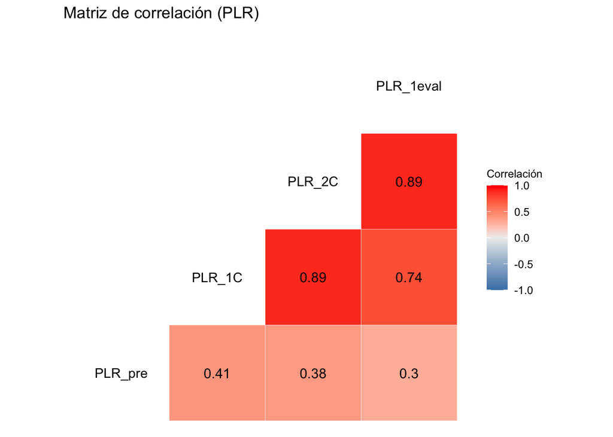

```r
# =====================
# MATRIZ DE CORRELACIÓN
# =====================
df_corr <- data %>% select(all_of(vars_PLR))

ggcorr(df_corr,
       label = TRUE,
       label_round = 2,
       label_size = 4,
       low = "steelblue", high = "red",
       name = "Correlación") +
  ggtitle("Matriz de correlación (PLR)")
```

Igual que NLR, podemos guardar la de prep y resumir el resto.

## PNI

```r
# Variables longitudinales de PNI
vars_PNI <- c("PNI_pre", "PNI_1C", "PNI_2C", "PNI_1eval")

# =====================
# GRÁFICO 1 - Color por Mejor_resp
# =====================
df_long1 <- data %>%
  select(Patient_ID, Mejor_resp, all_of(vars_PNI)) %>%
  pivot_longer(cols = all_of(vars_PNI), names_to = "Momento", values_to = "Valor") %>%
  mutate(Momento = factor(Momento, levels = vars_PNI))

g1 <- ggplot(df_long1, aes(
  x = Momento,
  y = Valor,
  group = Patient_ID,
  color = as.factor(Mejor_resp),
  text = paste(
    "Paciente:", Patient_ID,
    "<br>Momento:", Momento,
    "<br>Valor:", round(Valor, 2),
    "<br>Mejor respuesta:", Mejor_resp
  )
)) +
  geom_line(alpha = 0.7) +
  geom_point(size = 1.5, alpha = 0.9) +
  theme_minimal() +
  labs(
    title = "Evolución del PNI por paciente",
    subtitle = "Color según mejor respuesta al tratamiento",
    x = "Momento",
    y = "Valor PNI",
    color = "Mejor respuesta"
  )

ggplotly(g1, tooltip = "text")
```

[interactive chart not shown]

```r
# =====================
# GRÁFICO 2 - Color por First_eval
# =====================
df_long2 <- data %>%
  select(Patient_ID, First_eval, all_of(vars_PNI)) %>%
  pivot_longer(cols = all_of(vars_PNI), names_to = "Momento", values_to = "Valor") %>%
  mutate(Momento = factor(Momento, levels = vars_PNI))

g2 <- ggplot(df_long2, aes(
  x = Momento,
  y = Valor,
  group = Patient_ID,
  color = as.factor(First_eval),
  text = paste(
    "Paciente:", Patient_ID,
    "<br>Momento:", Momento,
    "<br>Valor:", round(Valor, 2),
    "<br>1ª evaluación:", First_eval
  )
)) +
  geom_line(alpha = 0.7) +
  geom_point(size = 1.5, alpha = 0.9) +
  theme_minimal() +
  labs(
    title = "Evolución del PNI por paciente",
    subtitle = "Color según 1ª evaluación",
    x = "Momento",
    y = "Valor PNI",
    color = "1ª evaluación"
  )

ggplotly(g2, tooltip = "text")
```

[interactive chart not shown]

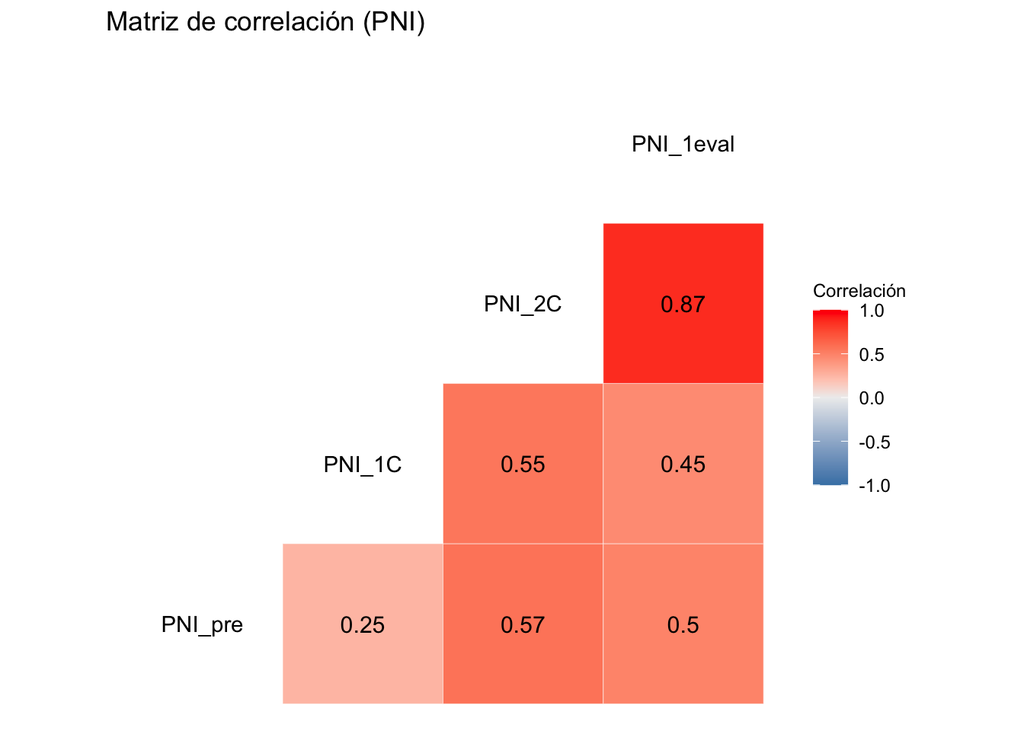

```r
# =====================
# MATRIZ DE CORRELACIÓN
# =====================
df_corr <- data %>% select(all_of(vars_PNI))

ggcorr(df_corr,
       label = TRUE,
       label_round = 2,
       label_size = 4,
       low = "steelblue", high = "red",
       name = "Correlación") +
  ggtitle("Matriz de correlación (PNI)")
```

Tenemos a PNI_1C como un punto intermedio, en cuanto a PNI_2C y PNI_1eval, la correlación es alta.

## SII

```r
# Variables longitudinales de SII
vars_SII <- c("SII_pre", "SII_1C", "SII_2C", "SII_1eval")

# =====================
# GRÁFICO 1 - Color por Mejor_resp
# =====================
df_long1 <- data %>%
  select(Patient_ID, Mejor_resp, all_of(vars_SII)) %>%
  pivot_longer(cols = all_of(vars_SII), names_to = "Momento", values_to = "Valor") %>%
  mutate(Momento = factor(Momento, levels = vars_SII))

g1 <- ggplot(df_long1, aes(
  x = Momento,
  y = Valor,
  group = Patient_ID,
  color = as.factor(Mejor_resp),
  text = paste(
    "Paciente:", Patient_ID,
    "<br>Momento:", Momento,
    "<br>Valor:", round(Valor, 2),
    "<br>Mejor respuesta:", Mejor_resp
  )
)) +
  geom_line(alpha = 0.7) +
  geom_point(size = 1.5, alpha = 0.9) +
  theme_minimal() +
  labs(
    title = "Evolución del SII por paciente",
    subtitle = "Color según mejor respuesta al tratamiento",
    x = "Momento",
    y = "Valor SII",
    color = "Mejor respuesta"
  )

ggplotly(g1, tooltip = "text")
```

[interactive chart not shown]

```r
# =====================
# GRÁFICO 2 - Color por First_eval
# =====================
df_long2 <- data %>%
  select(Patient_ID, First_eval, all_of(vars_SII)) %>%
  pivot_longer(cols = all_of(vars_SII), names_to = "Momento", values_to = "Valor") %>%
  mutate(Momento = factor(Momento, levels = vars_SII))

g2 <- ggplot(df_long2, aes(
  x = Momento,
  y = Valor,
  group = Patient_ID,
  color = as.factor(First_eval),
  text = paste(
    "Paciente:", Patient_ID,
    "<br>Momento:", Momento,
    "<br>Valor:", round(Valor, 2),
    "<br>1ª evaluación:", First_eval
  )
)) +
  geom_line(alpha = 0.7) +
  geom_point(size = 1.5, alpha = 0.9) +
  theme_minimal() +
  labs(
    title = "Evolución del SII por paciente",
    subtitle = "Color según 1ª evaluación",
    x = "Momento",
    y = "Valor SII",
    color = "1ª evaluación"
  )

ggplotly(g2, tooltip = "text")
```

[interactive chart not shown]

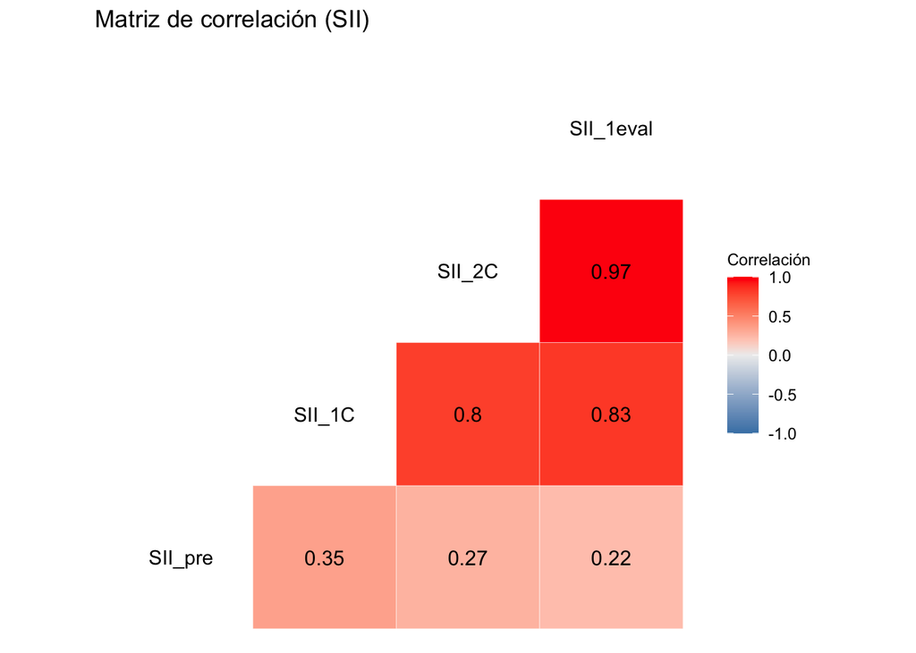

```r
# =====================
# MATRIZ DE CORRELACIÓN
# =====================
df_corr <- data %>% select(all_of(vars_SII))

ggcorr(df_corr,
       label = TRUE,
       label_round = 2,
       label_size = 4,
       low = "steelblue", high = "red",
       name = "Correlación") +
  ggtitle("Matriz de correlación (SII)")
```

Igual que con las otras, variables, SII_prep no muestra una clara correlación, en cambio, SII_1C, SII_*2C, SII_*1eval se podrían resumir en una sola variable.